# Model-Based Meta-Analysis of Oral Acetaminophen Pharmacokinetics

Using published aggregate data with the admixr2 R package

Author

Pramod BR

Published

July 22, 2026

# Summary

This report presents a **model-based meta-analysis (MBMA)** of the pharmacokinetics (PK) of oral immediate-release (IR) acetaminophen (paracetamol) in healthy adults. Rather than collecting new clinical data, it pools **summary-level results published in the literature** and fits a single structural PK model to them using the [`admixr2`](https://cran.r-project.org/package=admixr2) R package, which is built on the `nlmixr2`/`rxode2` ecosystem.

**Note**

# 1 Objectives

By the end of this project we:

- perform a systematic literature review;
- extract PK summary data from published studies;
- build an MBMA dataset;
- fit a structural PK model with `admixr2`;
- explore between-study variability;
- evaluate dose effects and other covariates;
- produce publication-quality figures;
- publish the reproducible workflow on GitHub.

# 2 Methods

## 2.1 Study selection

Eligible studies reported PK of **oral immediate-release acetaminophen in healthy adults**, with either summary PK parameters or a digitizable mean concentration–time profile. Selection followed a PICO framework (Population = healthy adults; Intervention = oral IR tablet/capsule; Comparator = none; Outcome = PK summaries). Modified-release, effervescent and liquid formulations, disease populations, and studies with absorption-altering co-medication were excluded. Full per-paper rationale is in `docs/literature_screening_log.xlsx`.

## 2.2 Data extraction and digitization

Reported values were standardized to a single unit system (concentration mg/L, exposure mg·h/L, time h, clearance L/h). Mean concentration–time curves were digitized from published figures using **WebPlotDigitizer**, capturing the mean at each time, the standard deviation from error bars, and the sample size. Digitization of published figures is an accepted method in evidence synthesis and pharmacometrics.

## 2.3 Structural model

The base model is a **one-compartment model with first-order absorption**. Because only apparent parameters are identifiable from oral-only data, we estimate apparent clearance (CL/F) and apparent volume (V/F). Parameters are mu-referenced on the log scale.

```r
oral_1cmt <- function() {
  ini({
    tka <- log(1.5); tcl <- log(21); tv <- log(60)
    prop.sd <- c(0, 0.2)
    eta.ka ~ 0.09; eta.cl ~ 0.09; eta.v ~ 0.09
  })
  model({
    ka <- exp(tka + eta.ka); cl <- exp(tcl + eta.cl); v <- exp(tv + eta.v)
    d/dt(depot)   <- -ka * depot
    d/dt(central) <-  ka * depot - (cl / v) * central
    cp <- central / v
    cp ~ prop(prop.sd)
  })
}
```

## 2.4 Fitting with admixr2

For each study, `admixr2` receives the mean concentration vector (E), its variance (V), sample size (n), observation times, and the dosing event. Fitting uses the Monte Carlo aggregate-data estimator (`est = "admc"`). Model selection uses the Akaike Information Criterion (AIC); covariate effects are explored by dose stratification.

# 3 Results

## 3.1 Structural parameters

```r
params <- read_if(file.path(res, "params_oral_1cmt.csv"))
if (!is.null(params)) kable(params, digits = 3) else cat("Run scripts/04_fit_model.R to generate this table.")
```

Fitted population PK parameters (one-compartment model), including derived exposure metrics.

| parameter | symbol | estimate | unit |
| --- | --- | --- | --- |
| Absorption rate constant (ka) | ka | 1.938 | 1/h |
| Apparent clearance (CL/F) | CL/F | 12.662 | L/h |
| Apparent volume of distribution (V/F) | V/F | 42.040 | L |
| Elimination rate constant (ke) | ke | 0.301 | 1/h |
| Elimination half-life (t1/2) | t1/2 | 2.301 | h |
| Time to peak at 1000 mg (Tmax) | Tmax | 1.137 | h |
| Peak concentration at 1000 mg (Cmax) | Cmax | 16.888 | mg/L |
| Exposure at 1000 mg (AUC0-inf) | AUC0-inf | 78.974 | mg*h/L |

## 3.2 Structural model comparison

```r
cmp <- read_if(file.path(res, "structural_model_comparison.csv"))
if (!is.null(cmp)) kable(cmp, digits = 2) else cat("Run scripts/04b_two_compartment.R to generate this table.")
```

One- vs two-compartment comparison. Lower AIC indicates the preferred model.

| model | n_par | obj_2LL | AIC | dAIC |
| --- | --- | --- | --- | --- |
| 1-compartment | 3 | 2383.56 | 2397.56 | 0.00 |
| 2-compartment | 5 | 2381.93 | 2399.93 | 2.37 |

The one-compartment model is preferred: the two-compartment version does not lower the AIC enough to justify its additional parameters.

## 3.3 Dose-stratified covariate analysis

```r
cov <- read_if(file.path(res, "covariate_stratified.csv"))
if (!is.null(cov)) kable(cov, digits = 3) else cat("Run scripts/05_covariate_analysis.R to generate this table.")
```

Model parameters estimated within dose strata.

| subgroup | n_arms | ka_per_h | clf_L_h | vf_L | obj_2LL | AIC |
| --- | --- | --- | --- | --- | --- | --- |
| All studies | 5 | 1.938 | 12.66 | 42.04 | 2383.56 | 2397.56 |
| Low dose (<=700 mg) | 4 | 2.747 | 13.36 | 47.61 | 1277.99 | 1291.99 |
| High dose (>=1000 mg) | 2 | 0.321 | 18.10 | 14.26 | 628.86 | 642.86 |

A shift in apparent parameters across dose strata is consistent with the known dose-dependence of oral acetaminophen bioavailability (Rawlins, 1977).

## 3.4 Diagnostic figures

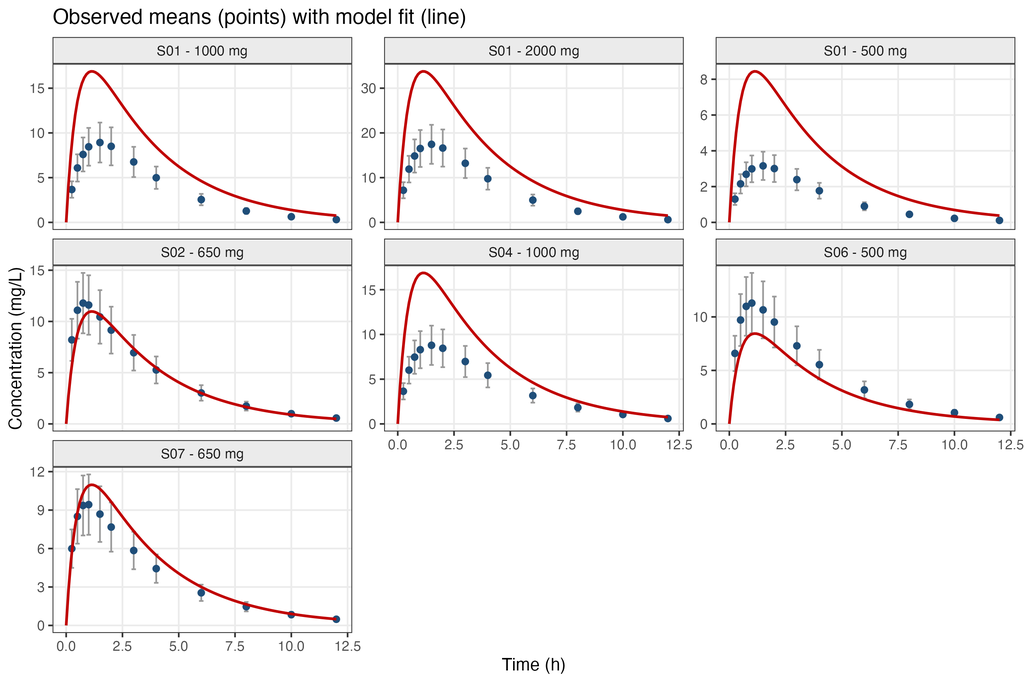

Figure 1: Observed means (points) with model fit (line), by study and dose.

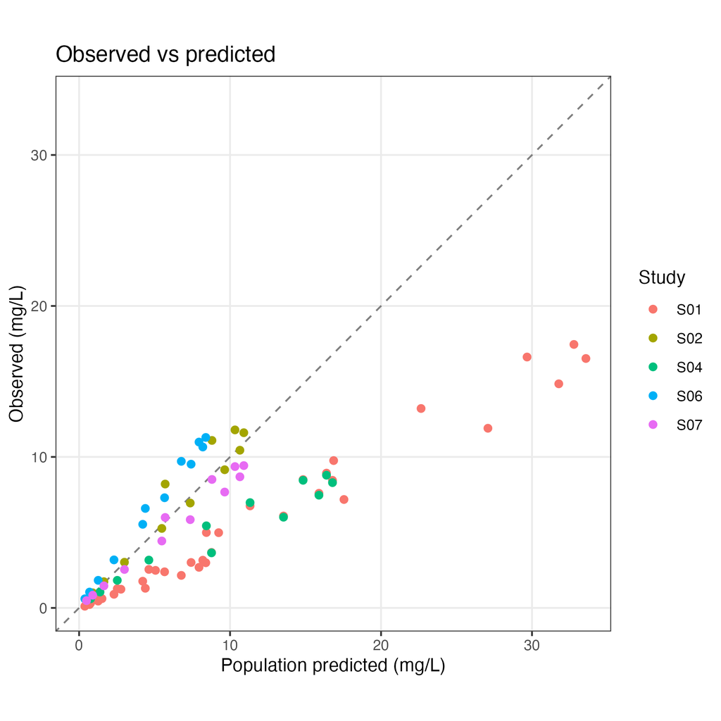

Figure 2: Observed vs population-predicted concentrations.

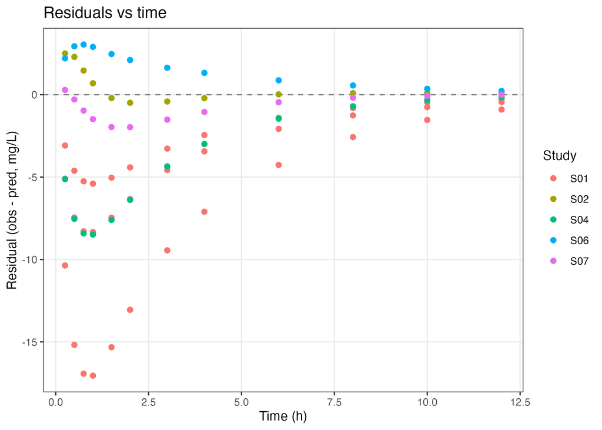

Figure 3: Residuals versus time.

## 3.5 Observed vs predicted concentrations

```r
conc <- read_if(file.path(res, "concentration_obs_pred.csv"))
if (!is.null(conc)) kable(head(conc, 12), digits = 3) else cat("Run scripts/06_plots.R to generate this table.")
```

First rows of the observed vs predicted concentration table (full table in results/).

| study_id | dose_mg | formulation | time_h | obs_conc_mg_L | obs_sd_mg_L | n | pred_conc_mg_L | residual_mg_L | source_ref |
| --- | --- | --- | --- | --- | --- | --- | --- | --- | --- |
| S01 | 500 | IR tablet | 0.25 | 1.300 | 0.325 | 6 | 4.386 | -3.086 | Rawlins 1977 (F,CL real; V,ka typical) |
| S01 | 500 | IR tablet | 0.50 | 2.154 | 0.539 | 6 | 6.770 | -4.616 | Rawlins 1977 (F,CL real; V,ka typical) |
| S01 | 500 | IR tablet | 0.75 | 2.687 | 0.672 | 6 | 7.943 | -5.256 | Rawlins 1977 (F,CL real; V,ka typical) |
| S01 | 500 | IR tablet | 1.00 | 2.991 | 0.748 | 6 | 8.392 | -5.401 | Rawlins 1977 (F,CL real; V,ka typical) |
| S01 | 500 | IR tablet | 1.50 | 3.159 | 0.790 | 6 | 8.194 | -5.035 | Rawlins 1977 (F,CL real; V,ka typical) |
| S01 | 500 | IR tablet | 2.00 | 3.008 | 0.752 | 6 | 7.418 | -4.410 | Rawlins 1977 (F,CL real; V,ka typical) |
| S01 | 500 | IR tablet | 3.00 | 2.391 | 0.598 | 6 | 5.663 | -3.272 | Rawlins 1977 (F,CL real; V,ka typical) |
| S01 | 500 | IR tablet | 4.00 | 1.767 | 0.442 | 6 | 4.215 | -2.448 | Rawlins 1977 (F,CL real; V,ka typical) |
| S01 | 500 | IR tablet | 6.00 | 0.902 | 0.226 | 6 | 2.311 | -1.409 | Rawlins 1977 (F,CL real; V,ka typical) |
| S01 | 500 | IR tablet | 8.00 | 0.450 | 0.113 | 6 | 1.265 | -0.815 | Rawlins 1977 (F,CL real; V,ka typical) |
| S01 | 500 | IR tablet | 10.00 | 0.224 | 0.056 | 6 | 0.693 | -0.469 | Rawlins 1977 (F,CL real; V,ka typical) |
| S01 | 500 | IR tablet | 12.00 | 0.111 | 0.028 | 6 | 0.379 | -0.268 | Rawlins 1977 (F,CL real; V,ka typical) |

# 4 Limitations

- Current estimates use a **bridge dataset**; final results require digitized real curves.
- The literature search was a **rapid scoping pass**; a formal PubMed + Embase search with two-reviewer screening is planned before publication.
- Because publications rarely report cross-time covariance, study variance is treated as a **diagonal** (per-time) matrix — a standard, mildly conservative approximation.

# 5 Reproducibility

The complete workflow runs with `source("scripts/run_all.R")`. Package versions are recorded in `results/sessionInfo.txt`. Source code and documentation are available at https://github.com/pbr26/MBMA_Acetaminophen_PK.

[session information not shown]